# When Sharks Attack: An analysis and visualization of trends in shark attack reports

I am a lover of all things sharks. Unfortunately, there is an abundance of misinformation about sharks and their behaviour, often creating the impression that sharks viciously hunt and attack humans. However, considering the circumstances under which shark attacks occur can help us mitigate risks and understand that attacks are both rare and not related to predation on humans. I am choosing to explore a data set recording logistical and forensic information from a collection of shark attacks occurring worldwide over a period of more than one hundred years. By analyzing the information in this data set, I am hoping to determine which conditions appear to be associated with increased incidence or risk of shark attacks.

The data set I am using for this project can be accessed through this link: https://www.kaggle.com/datasets/felipeesc/shark-attack-dataset/data

## Questions of interest

- Are there any geographical patterns in the incidence of shark attacks?
- What water activities are most associated with shark attacks?
- Are there any species of sharks that can be identified as more likely to attack than others?

```python
import pandas as pd
import numpy as np
import seaborn as sns
import matplotlib.pyplot as plt
```

## Reading in and cleaning the data

```python
#Reading in and adjusting the data frame to include only the rows and columns I am interested in
#i.e. contain data + relevant variables
attacks_full_df = pd.read_csv('attacks_1.csv')
attacks_uncleaned_df = attacks_full_df[0:6302] #removing empty rows at the end of the data set, only including rows that contain data
attacks_uncleaned_df_2 = attacks_uncleaned_df[['Date', 'Type', 'Country', 'Area', 'Location',
                         'Activity', 'Sex ', 'Age', 'Injury',
                         'Fatal (Y/N)', 'Time', 'Species ']] #not including variables such as Case Number which are not relevant for analysis
attacks_uncleaned_df_2 = attacks_uncleaned_df_2.set_index('Date')
attacks_uncleaned_df_2
```

| Date | Type | Country | Area | Location | Activity | Sex | Age | Injury | Fatal (Y/N) | Time | Species |
| --- | --- | --- | --- | --- | --- | --- | --- | --- | --- | --- | --- |
| 25-Jun-18 | Boating | USA | California | Oceanside, San Diego County | Paddling | F | 57 | No injury to occupant, outrigger canoe and pad... | N | 18h00 | White shark |
| 18-Jun-18 | Unprovoked | USA | Georgia | St. Simon Island, Glynn County | Standing | F | 11 | Minor injury to left thigh | N | 14h00 -15h00 | NaN |
| 09-Jun-18 | Invalid | USA | Hawaii | Habush, Oahu | Surfing | M | 48 | Injury to left lower leg from surfboard skeg | N | 07h45 | NaN |
| 08-Jun-18 | Unprovoked | AUSTRALIA | New South Wales | Arrawarra Headland | Surfing | M | NaN | Minor injury to lower leg | N | NaN | 2 m shark |
| 04-Jun-18 | Provoked | MEXICO | Colima | La Ticla | Free diving | M | NaN | Lacerations to leg & hand shark PROVOKED INCIDENT | N | NaN | Tiger shark, 3m |
| ... | ... | ... | ... | ... | ... | ... | ... | ... | ... | ... | ... |
| Before 1903 | Unprovoked | AUSTRALIA | Western Australia | Roebuck Bay | Diving | M | NaN | FATAL | Y | NaN | NaN |
| Before 1903 | Unprovoked | AUSTRALIA | Western Australia | NaN | Pearl diving | M | NaN | FATAL | Y | NaN | NaN |
| 1900-1905 | Unprovoked | USA | North Carolina | Ocracoke Inlet | Swimming | M | NaN | FATAL | Y | NaN | NaN |
| 1883-1889 | Unprovoked | PANAMA | NaN | Panama Bay 8ºN, 79ºW | NaN | M | NaN | FATAL | Y | NaN | NaN |
| 1845-1853 | Unprovoked | CEYLON (SRI LANKA) | Eastern Province | Below the English fort, Trincomalee | Swimming | M | 15 | FATAL. "Shark bit him in half, carrying away t... | Y | NaN | NaN |

6302 rows × 11 columns

```python
#Dealing with missing data
#attacks_uncleaned_df_2.isna().sum()
attacks_uncleaned_df_2['Age'].fillna(attacks_uncleaned_df['Age'].mode()[0], inplace = True)

def fill_missing(dataframe, items):
    for i in items:
        dataframe[i] = dataframe[i].fillna('Unknown')
    return dataframe

columns = ['Type', 'Country', 'Area', 'Location', 'Activity',
           'Sex ', 'Injury', 'Fatal (Y/N)', 'Time', 'Species ']
attacks_df = fill_missing(attacks_uncleaned_df_2, columns)
attacks_df
```

| Date | Type | Country | Area | Location | Activity | Sex | Age | Injury | Fatal (Y/N) | Time | Species |
| --- | --- | --- | --- | --- | --- | --- | --- | --- | --- | --- | --- |
| 25-Jun-18 | Boating | USA | California | Oceanside, San Diego County | Paddling | F | 57 | No injury to occupant, outrigger canoe and pad... | N | 18h00 | White shark |
| 18-Jun-18 | Unprovoked | USA | Georgia | St. Simon Island, Glynn County | Standing | F | 11 | Minor injury to left thigh | N | 14h00 -15h00 | Unknown |
| 09-Jun-18 | Invalid | USA | Hawaii | Habush, Oahu | Surfing | M | 48 | Injury to left lower leg from surfboard skeg | N | 07h45 | Unknown |
| 08-Jun-18 | Unprovoked | AUSTRALIA | New South Wales | Arrawarra Headland | Surfing | M | 17 | Minor injury to lower leg | N | Unknown | 2 m shark |
| 04-Jun-18 | Provoked | MEXICO | Colima | La Ticla | Free diving | M | 17 | Lacerations to leg & hand shark PROVOKED INCIDENT | N | Unknown | Tiger shark, 3m |
| ... | ... | ... | ... | ... | ... | ... | ... | ... | ... | ... | ... |
| Before 1903 | Unprovoked | AUSTRALIA | Western Australia | Roebuck Bay | Diving | M | 17 | FATAL | Y | Unknown | Unknown |
| Before 1903 | Unprovoked | AUSTRALIA | Western Australia | Unknown | Pearl diving | M | 17 | FATAL | Y | Unknown | Unknown |
| 1900-1905 | Unprovoked | USA | North Carolina | Ocracoke Inlet | Swimming | M | 17 | FATAL | Y | Unknown | Unknown |
| 1883-1889 | Unprovoked | PANAMA | Unknown | Panama Bay 8ºN, 79ºW | Unknown | M | 17 | FATAL | Y | Unknown | Unknown |
| 1845-1853 | Unprovoked | CEYLON (SRI LANKA) | Eastern Province | Below the English fort, Trincomalee | Swimming | M | 15 | FATAL. "Shark bit him in half, carrying away t... | Y | Unknown | Unknown |

6302 rows × 11 columns

### Sorting out the 'Species' Column

At this point in the data wrangling process, there are 1549 entry types in the species column. For example, attacks involving tiger sharks have been listed as 'Tiger shark', '2 m tiger shark', '3 m tiger shark', etc., though all these observations should be listed as 'Tiger Shark' for the purpose of data analysis. I reviewed the data to determine the different categories of shark species present, and wrote functions to replace entries containing relevant keywords with standard category names. Many of the entries had no species information, and included only information pertaining to the size of the shark, such as 'large', 'small', '0.9-2 m', etc. In these cases, I considered the species 'Unknown'.

```python
def replace_tiger(dataframe, column):
    mask = dataframe[column].str.contains('tiger', case = False)
    dataframe.loc[mask, column] = 'Tiger Shark'
    return dataframe


def replace_white(dataframe, column):
    mask = dataframe[column].str.contains('white', case = False)
    dataframe.loc[mask, column] = 'Great White Shark'
    return dataframe


def replace_reef(dataframe, column):
    mask = dataframe[column].str.contains('reef', case = False)
    dataframe.loc[mask, column] = 'Reef Shark'
    return dataframe


def replace_bull(dataframe, column):
    mask = dataframe[column].str.contains('bull', case = False)
    dataframe.loc[mask, column] = 'Bull Shark'
    return dataframe


def replace_nurse(dataframe, column):
    mask = dataframe[column].str.contains('nurse', case = False)
    dataframe.loc[mask, column] = 'Nurse Shark'
    return dataframe


def replace_hammer(dataframe, column):
    mask = dataframe[column].str.contains('hammer', case = False)
    dataframe.loc[mask, column] = 'Hammerhead Shark'
    return dataframe


def replace_lemon(dataframe, column):
    mask = dataframe[column].str.contains('lemon', case = False)
    dataframe.loc[mask, column] = 'Lemon Shark'
    return dataframe

def replace_multiple(dataframe, column):
    mask = dataframe[column].str.contains('sharks', case = False)
    dataframe.loc[mask, column] = 'Multiple Sharks'
    return dataframe

def replace_blue(dataframe, column):
    mask = dataframe[column].str.contains('blue', case = False)
    dataframe.loc[mask, column] = 'Blue Shark'
    return dataframe

def replace_blacktip(dataframe, column):
    mask = dataframe[column].str.contains('black', case = False)
    dataframe.loc[mask, column] = 'Blacktip Shark'
    return dataframe

def replace_wobbegong(dataframe, column):
    mask = dataframe[column].str.contains('wobbegong', case = False)
    dataframe.loc[mask, column] = 'Wobbegong Shark'
    return dataframe

def replace_dog(dataframe, column):
    mask = dataframe[column].str.contains('dog', case = False)
    dataframe.loc[mask, column] = 'Dog Shark'
    return dataframe

def replace_sand(dataframe, column):
    mask = dataframe[column].str.contains('sand', case = False)
    dataframe.loc[mask, column] = 'Sand Shark'
    return dataframe

def replace_ragged(dataframe, column):
    mask = dataframe[column].str.contains('ragged', case = False)
    dataframe.loc[mask, column] = 'Raggedtooth Shark'
    return dataframe

def replace_angel(dataframe, column):
    mask = dataframe[column].str.contains('angel', case = False)
    dataframe.loc[mask, column] = 'Angel Shark'
    return dataframe

def replace_basking(dataframe, column):
    mask = dataframe[column].str.contains('basking', case = False)
    dataframe.loc[mask, column] = 'Basking Shark'
    return dataframe

def replace_thresher(dataframe, column):
    mask = dataframe[column].str.contains('thresh', case = False)
    dataframe.loc[mask, column] = 'Thresher Shark'
    return dataframe

def replace_unknown_digits(dataframe, column):
    mask = dataframe[column].str.contains(r"\d", case = False)
    dataframe.loc[mask, column] = 'Unknown'
    return dataframe

def replace_unknown_other(dataframe, column, species):
    mask = ~dataframe[column].str.contains('|'.join(species), case = False)
    dataframe.loc[mask, column] = 'Unknown'
    return dataframe

attacks_df = replace_tiger(attacks_df, 'Species ')
attacks_df = replace_white(attacks_df, 'Species ')
attacks_df = replace_reef(attacks_df, 'Species ')
attacks_df = replace_bull(attacks_df, 'Species ')
attacks_df = replace_nurse(attacks_df, 'Species ')
attacks_df = replace_hammer(attacks_df, 'Species ')
attacks_df = replace_lemon(attacks_df, 'Species ')
attacks_df = replace_multiple(attacks_df, 'Species ')
attacks_df = replace_blue(attacks_df, 'Species ')
attacks_df = replace_blacktip(attacks_df, 'Species ')
attacks_df = replace_wobbegong(attacks_df, 'Species ')
attacks_df = replace_dog(attacks_df, 'Species ')
attacks_df = replace_sand(attacks_df, 'Species ')
attacks_df = replace_ragged(attacks_df, 'Species ')
attacks_df = replace_angel(attacks_df, 'Species ')
attacks_df = replace_basking(attacks_df, 'Species ')
attacks_df = replace_thresher(attacks_df, 'Species ')

attacks_df = replace_unknown_digits(attacks_df, 'Species ')
species = ['tiger', 'white', 'reef', 'bull', 'nurse', 'hammer',
           'lemon', 'multiple', 'blue', 'blacktip', 'wobbegong',
           'dog', 'sand', 'ragged', 'angel', 'basking', 'thresher']
attacks_df = replace_unknown_other(attacks_df, 'Species ', species)


attacks_df.sort_values('Species ').head(10)
```

| Date | Type | Country | Area | Location | Activity | Sex | Age | Injury | Fatal (Y/N) | Time | Species |
| --- | --- | --- | --- | --- | --- | --- | --- | --- | --- | --- | --- |
| Reported 08-Jul-2016 | Unprovoked | SPAIN | Canary Islands | Las Teresitas, Tenerife | Wading | F | 10 | 5 tiny puncture marks to lower leg, treated wi... | N | Unknown | Angel Shark |
| 20-Jul-14 | Unprovoked | SPAIN | Canary Islands | Teresita, Santa Cruz, Tenerife | Wading | Unknown | 17 | Minor injury | N | Unknown | Angel Shark |
| 28-Nov-10 | Provoked | NORTH ATLANTIC OCEAN | Georges Bank | Unknown | Fishing | M | 17 | Right hand severely bitten by netted shark PRO... | N | Unknown | Angel Shark |
| 17-Oct-09 | Provoked | SCOTLAND | Fife | Deep Sea World Aquarium | Diving | M | 23 | 15-20 puncture wounds to arm by captive shark ... | N | 14h45 | Angel Shark |
| 16-Jul-10 | Provoked | SPAIN | Grand Canary Island | Sardina del Norte, Gáldar | Swimming | M | 9 | Lacerations to left foot when he stepped on th... | N | 19h15 | Angel Shark |
| 17-Jul-06 | Unprovoked | USA | South Carolina | Singleton Beach, Hilton Head Island, Beaufort ... | Standing | M | 49 | Left ankle & foot bitten | N | 10h00 | Angel Shark |
| 26-Feb-99 | Boating | USA | North Carolina | Frying Pan Shoals | Cruising | Unknown | 17 | No injury to occupants, boat sank after collid... | N | Unknown | Basking Shark |
| 12-Sep-37 | Boating | SCOTLAND | Argyllshire | Arran | Pleasure boating | Unknown | 17 | No injury to occupants, two 5-foot observation... | N | Unknown | Basking Shark |
| 11-Sep-37 | Boating | SCOTLAND | Arran | Fallen Rocks | Fishing | Unknown | 17 | No injury to occupants, propeller shaft damaged | N | Unknown | Basking Shark |
| Before 1908 | Unprovoked | USA | California | Monterey, Montery County | Fishing for basking sharks | M | 17 | FATAL PROVOKED INCIDENTS | Y | Unknown | Basking Shark |

## Which Shark Species are Most Likely to Attack?

Even though the data has been cleaned and sorted, in most attacks the species of shark involved was unknown. As we can see from a preliminary plot, most of the cases where the species was known are obscured by the cases where it was not.

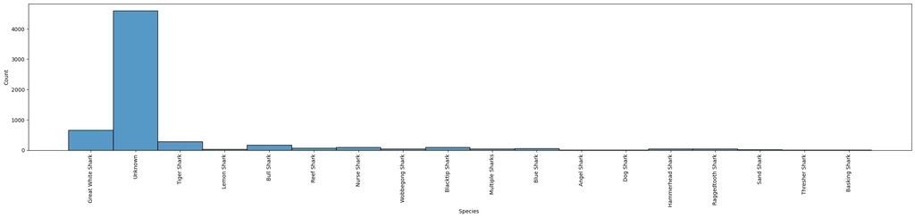

```python
#Preliminary plot
fig, ax = plt.subplots(figsize = (30, 5))
sns.histplot(data = attacks_df, x = 'Species ')
plt.xticks(rotation = 90)
plt.show()
```

### What can be done?

In an attempt to analyze the data and draw some conclusions, I will perform bootstrap sampling on the data where the species of shark was known, to get an idea of which species of sharks may be more likely to be involved in an attack.

```python
#Creating a new data frame with filtered species data
species_known_df = attacks_df[attacks_df['Species '] != 'Unknown']
species_known_df
```

| Date | Type | Country | Area | Location | Activity | Sex | Age | Injury | Fatal (Y/N) | Time | Species |
| --- | --- | --- | --- | --- | --- | --- | --- | --- | --- | --- | --- |
| 25-Jun-18 | Boating | USA | California | Oceanside, San Diego County | Paddling | F | 57 | No injury to occupant, outrigger canoe and pad... | N | 18h00 | Great White Shark |
| 04-Jun-18 | Provoked | MEXICO | Colima | La Ticla | Free diving | M | 17 | Lacerations to leg & hand shark PROVOKED INCIDENT | N | Unknown | Tiger Shark |
| 03-Jun-18 | Unprovoked | BRAZIL | Pernambuco | Piedade Beach, Recife | Swimming | M | 18 | FATAL | Y | Late afternoon | Tiger Shark |
| 27-May-18 | Unprovoked | USA | Florida | Lighhouse Point Park, Ponce Inlet, Volusia County | Fishing | M | 52 | Minor injury to foot. PROVOKED INCIDENT | N | Unknown | Lemon Shark |
| 26-May-18 | Unprovoked | USA | Florida | Cocoa Beach, Brevard County | Walking | M | 15 | Lower left leg bitten | N | 17h00 | Bull Shark |
| ... | ... | ... | ... | ... | ... | ... | ... | ... | ... | ... | ... |
| Early 1930s | Unprovoked | BELIZE | Unknown | Unknown | Standing | M | 16 | FATAL | Y | Unknown | Tiger Shark |
| Before 1906 | Unprovoked | AUSTRALIA | Unknown | Unknown | Fishing | M | 17 | FATAL, knocked overboard by tail of shark & ca... | Y | Unknown | Blue Shark |
| Before 1906 | Unprovoked | AUSTRALIA | Unknown | Unknown | Fishing | M | 17 | FATAL | Y | Unknown | Blue Shark |
| Before 1906 | Unprovoked | AUSTRALIA | Unknown | Unknown | Fishing | M | 17 | FATAL | Y | Unknown | Blue Shark |
| Before 1906 | Unprovoked | AUSTRALIA | New South Wales |  | Swimming | M | 17 | FATAL | Y | Unknown | Nurse Shark |

1704 rows × 11 columns

```python
#Creating 1000 bootstrap samples
boot1000_species = pd.concat([species_known_df.sample(frac=1, replace = True).assign(replicate = n) for n in range(1000)])
boot1000_species
```

| Date | Type | Country | Area | Location | Activity | Sex | Age | Injury | Fatal (Y/N) | Time | Species | replicate |
| --- | --- | --- | --- | --- | --- | --- | --- | --- | --- | --- | --- | --- |
| 24-Aug-76 | Unprovoked | USA | Oregon | Winchester Bay | Surfing | M | 19 | No injury, board bitten | N | 14h00 | Great White Shark | 0 |
| 15-Apr-18 | Unprovoked | THAILAND | Hua Hin | Sai Noi Beach | Swimming | M | 54 | Lacerations to foot and ankle | N | Unknown | Bull Shark | 0 |
| 07-May-96 | Unprovoked | USA | Florida | Shark Shallows, Ponce Inlet, Volusia County | Surfing | M | 27 | Left foot & leg bitten | N | 11h06 | Blacktip Shark | 0 |
| 1982 | Boat | ITALY | Tyrrhenian Sea | Biodola, Isola d'Elba | Fishing on a boat | M | 17 | No injury | N | Unknown | Great White Shark | 0 |
| 05-Jan-66 | Unprovoked | USA | Florida | Hollywood, Broward County | Swimming | M | 35 | Thigh gashed | N | 16h00 | Hammerhead Shark | 0 |
| ... | ... | ... | ... | ... | ... | ... | ... | ... | ... | ... | ... | ... |
| 08-Jan-05 | Boating | NEW ZEALAND | North Island | Taupiri Bay | Fishing from a kayak | M | 39 | No injury, kayak bumped repeatedly | N | 12h00 | Great White Shark | 999 |
| 14-Apr-18 | Unprovoked | BAHAMAS | New Providence | Nirvana Beach | Surfing | M | 17 | No Injury. Shark swam away with the surf board | N | 09h30 | Tiger Shark | 999 |
| 09-Jul-94 | Unprovoked | SOUTH AFRICA | Eastern Cape Province | Nahoon Beach, East London | Surfing | M | 22 | FATAL, leg severed | Y | 13h26 | Great White Shark | 999 |
| 27-Nov-04 | Unprovoked | SOUTH AFRICA | Eastern Cape Province | Nahoon, East London | Surfing | M | 20 | 3 lacerations on foot | N | 18h00 | Raggedtooth Shark | 999 |
| 14-Oct-84 | Unprovoked | USA | Florida | Bob Graham Beach, Martin County | Surfing | M | 15 | Left calf bitten | N | 15h00 | Blacktip Shark | 999 |

1704000 rows × 12 columns

```python
#Summarizing the trends in the bootstrapped samples
species_frequency = boot1000_species['Species '].value_counts()
species_proportions = species_frequency/species_frequency.sum()

species_summary = pd.DataFrame({'Species' : species_frequency.index,
                                'Frequency' : species_frequency.values,
                                'Proportion' : species_proportions.values})
species_summary
```

|  | Species | Frequency | Proportion |
| --- | --- | --- | --- |
| 0 | Great White Shark | 664864 | 0.390178 |
| 1 | Tiger Shark | 285427 | 0.167504 |
| 2 | Bull Shark | 175923 | 0.103241 |
| 3 | Nurse Shark | 97059 | 0.056960 |
| 4 | Blacktip Shark | 92184 | 0.054099 |
| 5 | Reef Shark | 66121 | 0.038803 |
| 6 | Blue Shark | 52641 | 0.030893 |
| 7 | Wobbegong Shark | 49905 | 0.029287 |
| 8 | Hammerhead Shark | 48251 | 0.028316 |
| 9 | Multiple Sharks | 44904 | 0.026352 |
| 10 | Raggedtooth Shark | 43176 | 0.025338 |
| 11 | Lemon Shark | 33672 | 0.019761 |
| 12 | Sand Shark | 23134 | 0.013576 |
| 13 | Dog Shark | 9818 | 0.005762 |
| 14 | Basking Shark | 7048 | 0.004136 |
| 15 | Angel Shark | 5914 | 0.003471 |
| 16 | Thresher Shark | 3959 | 0.002323 |

```python
#Create a new data frame with the proportions of each species involved in attacks in each sample
boot_species_proportions = boot1000_species.groupby('replicate')['Species '].value_counts(normalize = True)
boot_species_proportions_df = pd.DataFrame(boot_species_proportions)
```

```python
#Calculate the mean proportion of attack involvement for the most frequently occurring species
great_white = boot1000_species[boot1000_species['Species '] == 'Great White Shark']
great_white_prprtns = great_white.groupby('replicate').size()/boot1000_species.groupby('replicate').size()
great_white_mean = great_white_prprtns.mean()

tiger = boot1000_species[boot1000_species['Species '] == 'Tiger Shark']
tiger_prprtns = tiger.groupby('replicate').size()/boot1000_species.groupby('replicate').size()
tiger_mean = tiger_prprtns.mean()

bull = boot1000_species[boot1000_species['Species '] == 'Bull Shark']
bull_prprtns = bull.groupby('replicate').size()/boot1000_species.groupby('replicate').size()
bull_mean = bull_prprtns.mean()

print(f"The mean proportion of attack involvement was {round(great_white_mean, 2)} for Great White sharks")
print(f"The mean proportion of attack involvement was {round(tiger_mean, 2)} for Tiger sharks")
print(f"The mean proportion of attack involvement was {round(bull_mean, 2)} for Bull sharks")
```

```
The mean proportion of attack involvement was 0.39 for Great White sharks
The mean proportion of attack involvement was 0.17 for Tiger sharks
The mean proportion of attack involvement was 0.1 for Bull sharks
```

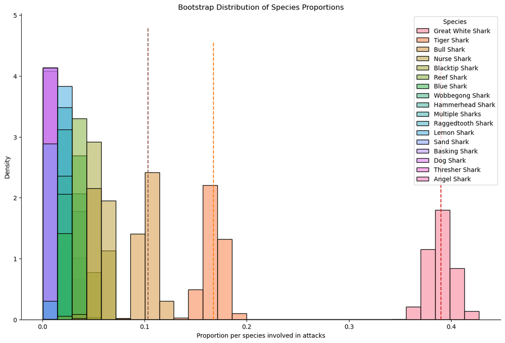

```python
#Plotting the bootstrap distribution
fig, ax = plt.subplots(figsize = (14, 9))
sns.histplot(data = boot_species_proportions_df, x = 'proportion', hue = 'Species ',
             stat = 'density', bins = 30)
ax.set_xlabel('Proportion per species involved in attacks')
ax.set_ylabel('Density')
ax.set_title('Bootstrap Distribution of Species Proportions')
ax.vlines(0.39019424882629106, 0, ax.get_ylim()[1], color = 'tab:red', linestyle = '--')
ax.vlines(0.1672523474178404, 0, ax.get_ylim()[1], color = 'tab:orange', linestyle = '--')
ax.vlines(0.10320422535211267, 0, ax.get_ylim()[1], color = 'tab:brown', linestyle = '--')
ax.spines[['top', 'right']].set_visible(False)
plt.show()
```

## Geographical Patterns in Shark Attacks

Based on a preliminary plot, there are a number of countries with much greater contributions to the number of worldwide shark attacks than others. To simplify this analysis, I will focus on the ten countries with the greatest number of attacks in the dataset.

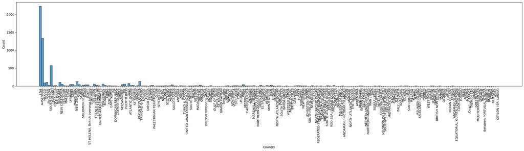

```python
#Preliminary plot
fig, ax = plt.subplots(figsize = (30, 5))
sns.histplot(data = attacks_df, x = 'Country')
plt.xticks(rotation = 90)
plt.show()
```

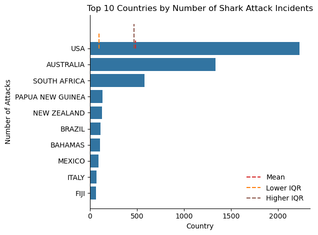

```python
country_frequency = attacks_df['Country'].value_counts().reset_index()
#country_frequency.head(50)
top_10_countries = country_frequency[0:10]
top_10_countries
#top_10_countries.describe()

fig, ax = plt.subplots()
sns.barplot(data = top_10_countries, x = 'count', y = 'Country')
ax.set_xlabel('Country')
ax.set_ylabel('Number of Attacks')
ax.set_title('Top 10 Countries by Number of Shark Attack Incidents')
ax.vlines(485.1, 0, ax.get_ylim()[1], color = 'tab:red', linestyle = '--', label = 'Mean')
ax.vlines(94, 0, ax.get_ylim()[1], color = 'tab:orange', linestyle = '--', label = 'Lower IQR')
ax.vlines(467.75, 0, ax.get_ylim()[1], color = 'tab:brown', linestyle = '--', label = 'Higher IQR')
ax.spines[['top', 'right']].set_visible(False)
plt.legend(frameon = False)
plt.tight_layout()
plt.show()
```

Already, we can see that the USA is strongly influencing the average number of shark attacks globally, bringing the average number of attacks even about the boundaries of the interquartile range. Further analysis of the most affected countries can further reveal geographical trends.

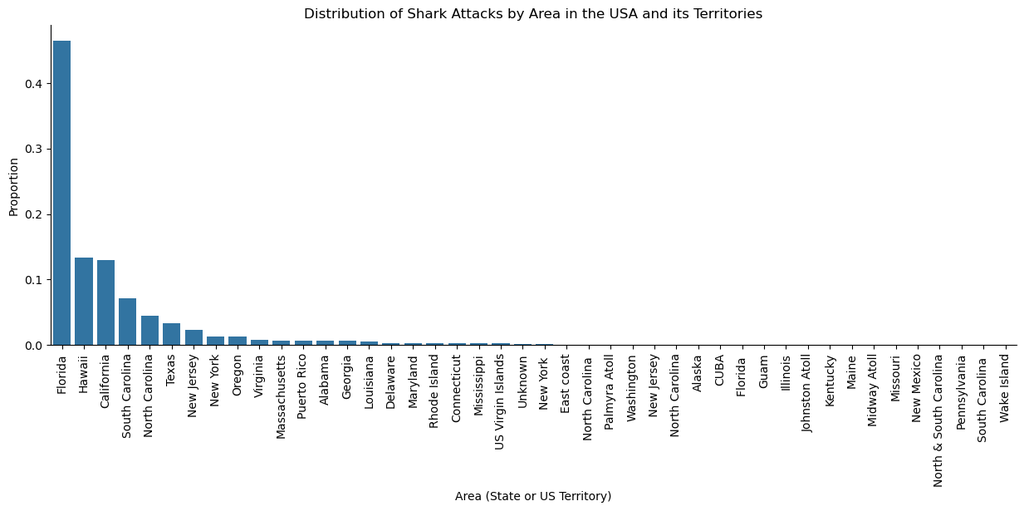

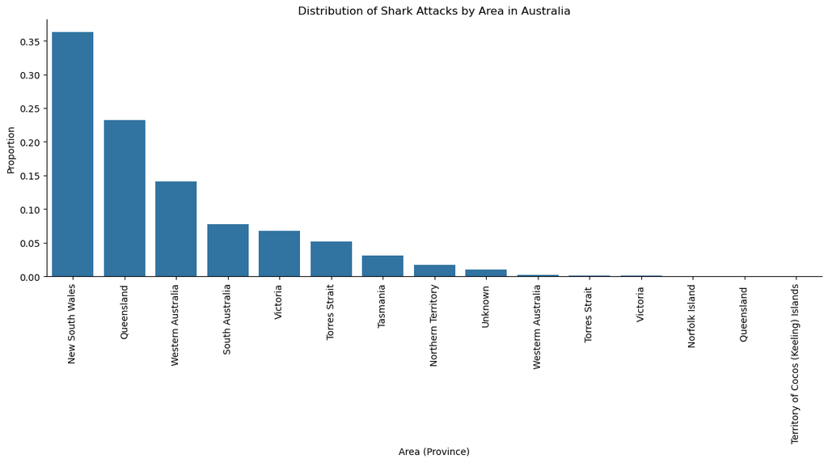

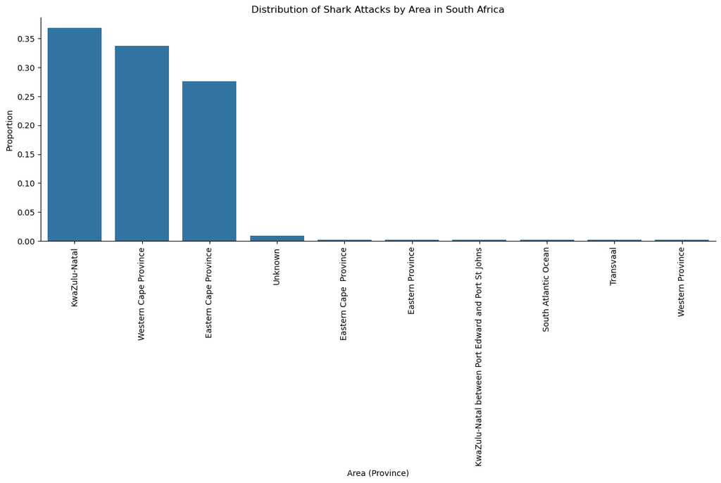

```python
#Breaking down attacks by area in common countries
#USA
usa_data = attacks_df[attacks_df['Country'] == 'USA']
usa_regions = usa_data.groupby('Country')['Area'].value_counts(normalize = True)
usa_df = pd.DataFrame(usa_regions)

fig, ax = plt.subplots(figsize = (15, 5))
sns.barplot(data = usa_df, x = 'Area', y = 'proportion')
ax.set_xlabel('Area (State or US Territory)')
ax.set_ylabel('Proportion')
ax.set_title('Distribution of Shark Attacks by Area in the USA and its Territories')
ax.spines[['top', 'right']].set_visible(False)
plt.xticks(rotation = 90)

#Australia
australia_data = attacks_df[attacks_df['Country'] == 'AUSTRALIA']
australia_regions = australia_data.groupby('Country')['Area'].value_counts(normalize = True)
australia_df = pd.DataFrame(australia_regions)

fig, ax = plt.subplots(figsize = (15, 5))
sns.barplot(data = australia_df, x = 'Area', y = 'proportion')
ax.set_xlabel('Area (Province)')
ax.set_ylabel('Proportion')
ax.set_title('Distribution of Shark Attacks by Area in Australia')
ax.spines[['top', 'right']].set_visible(False)
plt.xticks(rotation = 90)

#South Africa
south_africa_data = attacks_df[attacks_df['Country'] == 'SOUTH AFRICA']
south_africa_regions = south_africa_data.groupby('Country')['Area'].value_counts(normalize = True)
south_africa_df = pd.DataFrame(south_africa_regions)

fig, ax = plt.subplots(figsize = (15, 5))
sns.barplot(data = south_africa_df, x = 'Area', y = 'proportion')
ax.set_xlabel('Area (Province)')
ax.set_ylabel('Proportion')
ax.set_title('Distribution of Shark Attacks by Area in South Africa')
plt.xticks(rotation = 90)
ax.spines[['top', 'right']].set_visible(False)
plt.show()
```

### Reflecting on the data

By further decomposing the number of attacks in each country by area, we can see which regions have the strongest influences on the trends in their respective country. We can see, for example, that states in the southern USA are the primary contributors to USA shark attacks, which is logical given their proximity to warm coastal waters where shark activity in shallow waters is greater (Neff & Hueter, 2013).

## What Activities have the Potential to Increase Risk of Shark Attacks?

Much like the species data, there are a staggering number of entry types for the activity the victims were participating in at the time of the attacks. A preliminary plot shows that this data is currently not very useful for analysis and should be processed in a similar way to the species data in order to be meaningful.

```python
attacks_df['Activity'].nunique()
```

```
1532
```

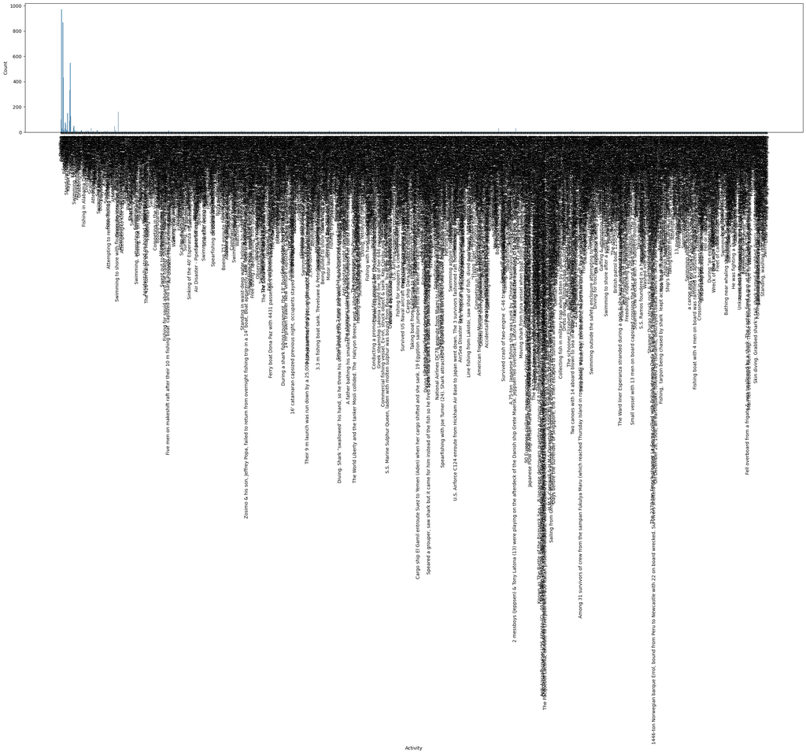

```python
#Preliminary plot
fig, ax = plt.subplots(figsize = (30, 5))
sns.histplot(data = attacks_df, x = 'Activity')
plt.xticks(rotation = 90)
plt.show()
```

### Sorting out the 'Activity' column

Note that for entries involving fishing and/or boating, I sorted the data into 'Fishing', 'Boating', 'Fishing from a boat', and 'Shipwreck' categories within one function to avoid miscategorizing the data, as many relevant keywords overlapped between these categories.

```python
def replace_swim(dataframe, column):
    mask = dataframe[column].str.contains('swim', case = False)
    dataframe.loc[mask, column] = 'Swimming'
    return dataframe

def replace_surf(dataframe, column):
    mask = dataframe[column].str.contains('surf', case = False)
    dataframe.loc[mask, column] = 'Surfing'
    return dataframe

def replace_board(dataframe, column):
    mask = dataframe[column].str.contains('board', case = False)
    dataframe.loc[mask, column] = 'Surfing'
    return dataframe

def replace_bath(dataframe, column):
    mask = dataframe[column].str.contains('bath', case = False)
    dataframe.loc[mask, column] = 'Bathing'
    return dataframe

def replace_dive(dataframe, column):
    mask = dataframe[column].str.contains('div', case = False)
    dataframe.loc[mask, column] = 'Diving'
    return dataframe

def replace_lasso(dataframe, column):
    mask = dataframe[column].str.contains('lasso', case = False)
    dataframe.loc[mask, column] = 'Attempting to lasso/catch the shark'
    return dataframe

def replace_rescue(dataframe, column):
    mask = dataframe[column].str.contains('rescue', case = False)
    dataframe.loc[mask, column] = 'Rescue'
    return dataframe

def replace_collect(dataframe, column):
    mask = dataframe[column].str.contains('collect', case = False)
    dataframe.loc[mask, column] = 'Collecting shells or other marine objects'
    return dataframe

def replace_crossing(dataframe, column):
    mask = dataframe[column].str.contains('cross', case = False)
    dataframe.loc[mask, column] = 'Crossing a body of water'
    return dataframe

def replace_provoke(dataframe, column):
    free_mask = dataframe[column].str.contains('free', case = False)
    chase_mask = dataframe[column].str.contains('chase', case = False)
    catch_mask = dataframe[column].str.contains('catch', case = False)
    hook_mask = dataframe[column].str.contains('hook', case = False)
    fists_mask = dataframe[column].str.contains('fists', case = False)
    drive_mask = dataframe[column].str.contains('drive', case = False)
    kill_mask = dataframe[column].str.contains('kill', case = False)
    ride_mask = dataframe[column].str.contains('ride', case = False)
    net_mask = dataframe[column].str.contains('net', case = False)
    dataframe.loc[free_mask | chase_mask | catch_mask | hook_mask | fists_mask | drive_mask | kill_mask
    | ride_mask | net_mask] = 'Provoked/Chose to interact with shark'
    return dataframe

def replace_fish_and_boat(dataframe, column):
    fish_mask = dataframe[column].str.contains('fish', case = False)
    boat_mask = dataframe[column].str.contains('boat', case = False)
    shipwreck_mask = dataframe[column].str.contains('sink', case = False)
    shipwreck_mask_2 = dataframe[column].str.contains('sank', case = False)
    shipwreck_mask_3 = dataframe[column].str.contains('sunk', case = False)
    overboard_mask = dataframe[column].str.contains('overboard', case = False)
    adrift_mask = dataframe[column].str.contains('adrift', case = False)
    abandon_mask = dataframe[column].str.contains('abandon', case = False)
    capsize_mask = dataframe[column].str.contains('capsize', case = False)
    raft_mask = dataframe[column].str.contains('raft', case = False)
    plane_mask = dataframe[column].str.contains('plane', case = False)
    plane_mask_2 = dataframe[column].str.contains('air', case = False)
    accident_mask = dataframe[column].str.contains('accident', case = False)
    dataframe.loc[fish_mask & boat_mask & ~shipwreck_mask & ~shipwreck_mask_2 & ~shipwreck_mask_3
    & ~overboard_mask & ~adrift_mask & ~abandon_mask & ~capsize_mask & ~raft_mask & ~plane_mask & ~plane_mask_2
    & ~accident_mask, column] = 'Fishing from a Boat'
    dataframe.loc[fish_mask & ~boat_mask, column] = 'Fishing'
    dataframe.loc[boat_mask & ~fish_mask & ~shipwreck_mask & ~shipwreck_mask_2 & ~shipwreck_mask_3
    & ~overboard_mask & ~adrift_mask & ~abandon_mask & ~capsize_mask & ~raft_mask & ~plane_mask & ~plane_mask_2
    & ~accident_mask, column] = 'Boating'
    dataframe.loc[shipwreck_mask | shipwreck_mask_2 | shipwreck_mask_3| overboard_mask | adrift_mask | abandon_mask
    | capsize_mask | raft_mask | plane_mask | plane_mask_2 | accident_mask ] = 'Shipwreck or Plane Crash'
    return dataframe

def replace_other(dataframe, column, activity):
    mask = ~dataframe[column].str.contains('|'.join(activity), case = False)
    dataframe.loc[mask, column] = 'Other'
    return dataframe

attacks_df = replace_swim(attacks_df, 'Activity')
attacks_df = replace_surf(attacks_df, 'Activity')
attacks_df = replace_board(attacks_df, 'Activity')
attacks_df = replace_bath(attacks_df, 'Activity')
attacks_df = replace_fish_and_boat(attacks_df, 'Activity')
attacks_df = replace_dive(attacks_df, 'Activity')
attacks_df = replace_lasso(attacks_df, 'Activity')
attacks_df = replace_rescue(attacks_df, 'Activity')
attacks_df = replace_collect(attacks_df, 'Activity')
attacks_df = replace_provoke(attacks_df, 'Activity')
attacks_df = replace_crossing(attacks_df, 'Activity')


activities = ['swim', 'surf', 'board', 'bath', 'div', 'rescue', 'collect', 'free', 'chase', 'catch', 'hook', 'fists', 'drive',
             'kill', 'ride', 'net', 'fish', 'boat', 'sink', 'sank', 'sunk', 'overboard', 'adrift', 'abandon', 'capsize', 'raft',
              'plane', 'air', 'accident']
attacks_df = replace_other(attacks_df, 'Activity', activities)


attacks_df.sort_values('Activity').head(10)
```

| Date | Type | Country | Area | Location | Activity | Sex | Age | Injury | Fatal (Y/N) | Time | Species |
| --- | --- | --- | --- | --- | --- | --- | --- | --- | --- | --- | --- |
| 14-Dec-22 | Unprovoked | USA | Puerto Rico | San Juan | Bathing | F | 17 | FATAL, hip & thigh bitten with tissue removed... | Y | Unknown | Unknown |
| 02-Feb-1959 Reported | Unprovoked | SOLOMON ISLANDS | Guadalcanal Province | Trench’s Beach, Guadalcanal Island | Bathing | M | 15 | FATAL, body not recovered | Y | 17h00 | Unknown |
| 30-Apr-1830 | Unprovoked | INDIA | Tamil Nadu | St. Thomé | Bathing | M | 17 | FATAL | Y | 17h00-18h00 | Unknown |
| 26-Mar-05 | Unprovoked | AUSTRALIA | New South Wales | Lismore | Bathing | M | 40 | Righ thigh severely bitten | N | Morning | Unknown |
| Before 1905 | Unprovoked | BURMA | Unknown | Unknown | Bathing | M | 17 | Fatal x 2 | Y | Unknown | Unknown |
| 21-Aug-00 | Unprovoked | USA | North Carolina | Southport, Brunswick County | Bathing | M | 17 | Left hand lacerated | N | Afternoon | Unknown |
| 04-Nov-1845 | Unprovoked | MEXICO | Vera Cruz | Vera Cruz | Bathing | M | 17 | FATAL | Y | Unknown | Unknown |
| 10-Jan-1863 | Unprovoked | AUSTRALIA | New South Wales | "Bellynahinch" on the Manning River | Bathing | M | 17 | FATAL | Y | Evening | Unknown |
| 1850 | Unprovoked | NICARAGUA | Lake Nicaragua (fresh water) | Granada, Granada Department | Bathing | M | 17 | FATAL | Y | Unknown | Unknown |
| 1939 | Unprovoked | VENEZUELA | Carabobo | El Falito, near Puerto Cabello | Bathing | M | 17 | FATAL. | Y | Unknown | Unknown |

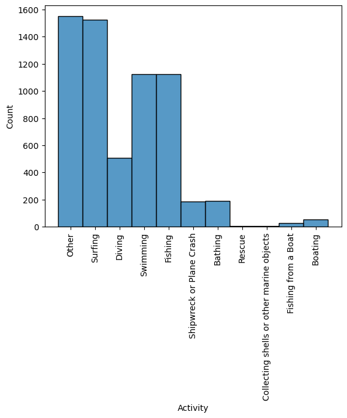

```python
#Plot of the re-categorized data
fig, ax = plt.subplots()
sns.histplot(data = attacks_df, x = 'Activity')
plt.xticks(rotation = 90)
plt.show()
```

Though there are more cases where the activity was clearly known than was seen with the Species data, there are still a number of unknowns with the Activity data. In order to attempt to draw some conclusions, I will repeat the bootstrapping process on the activity data.

```python
# Filtering the data and creating a set of 1000 bootstrap samples
activities_known_df = attacks_df[attacks_df['Activity'] != 'Other']
boot1000_activities = pd.concat([activities_known_df.sample(frac=1, replace = True).assign(replicate = n) for n in range(1000)])
boot1000_activities
```

| Date | Type | Country | Area | Location | Activity | Sex | Age | Injury | Fatal (Y/N) | Time | Species | replicate |
| --- | --- | --- | --- | --- | --- | --- | --- | --- | --- | --- | --- | --- |
| 17-Jun-89 | Unprovoked | USA | Louisiana | 40 miles off Cocodrie | Fishing | M | 45 | Puncture wounds & lacerations to both legs | N | Unknown | Tiger Shark | 0 |
| 10-Jun-04 | Unprovoked | USA | Florida | Daytona Beach Shores, Volusia County | Swimming | M | 8 | Right wrist & left arm lacerated | N | 18h00 | Unknown | 0 |
| Summer 1943 | Unprovoked | MEXICO | Veracruz | Villa del Mar Beach, Veracruz | Swimming | Unknown | 17 | FATAL | Y | Unknown | Unknown | 0 |
| 21-Oct-78 | Invalid | SOUTH AFRICA | KwaZulu-Natal | Fishing camp, St. Lucia Estuary | Fishing | M | 17 | FATAL or scavenging by 3 m tiger shark (may ha... | Unknown | Dusk | Unknown | 0 |
| 24-Jan-09 | Unprovoked | SOUTH AFRICA | Eastern Cape Province | Second Beach, Port St. John's | Swimming | M | 25 | FATAL | Y | 14h00 | Tiger Shark | 0 |
| ... | ... | ... | ... | ... | ... | ... | ... | ... | ... | ... | ... | ... |
| 02-Sep-17 | Unprovoked | USA | Florida | New Smyrna Beach, Volusia County | Surfing | M | 17 | Minor injury to right hand | N | 10h44 | Unknown | 999 |
| 01-Nov-59 | Provoked | PAPUA NEW GUINEA | New Britain | Rapindik Beach, Rabaul | Fishing | M | 17 | Both hands bitten while helping companion land... | N | Unknown | Unknown | 999 |
| 01-May-50 | Boating | ITALY | Tyrrhenian Sea | Sprizze, Isola d'Elba | Fishing from a Boat | M | 17 | No injury | N | Unknown | Great White Shark | 999 |
| 11-Apr-17 | Unprovoked | USA | Florida | Ormond Beach, Volusia County | Surfing | F | 35 | Calf bitten | N | 16h00 | Unknown | 999 |
| 29-Sep-03 | Unprovoked | FIJI | Taveuni | Welagi coastal reef off Drekeniwai | Boating | M | 40 | FATAL abdomen bitten | Y | Night | Unknown | 999 |

4751000 rows × 12 columns

```python
#Summarizing the trends in the bootstrapped samples
activities_frequency = boot1000_activities['Activity'].value_counts()
activities_proportions = activities_frequency/activities_frequency.sum()

activities_summary = pd.DataFrame({'Activity' : activities_frequency.index,
                                'Frequency' : activities_frequency.values,
                                'Proportion' : activities_proportions.values})
activities_summary
```

|  | Activity | Frequency | Proportion |
| --- | --- | --- | --- |
| 0 | Surfing | 1525747 | 0.321142 |
| 1 | Fishing | 1125054 | 0.236804 |
| 2 | Swimming | 1122434 | 0.236252 |
| 3 | Diving | 509769 | 0.107297 |
| 4 | Bathing | 188734 | 0.039725 |
| 5 | Shipwreck or Plane Crash | 184955 | 0.038930 |
| 6 | Boating | 54038 | 0.011374 |
| 7 | Fishing from a Boat | 26432 | 0.005563 |
| 8 | Rescue | 6961 | 0.001465 |
| 9 | Collecting shells or other marine objects | 6876 | 0.001447 |

```python
#Create a new data frame with the proportions of each activity involved in attacks in each sample
boot_activities_proportions = boot1000_activities.groupby('replicate')['Activity'].value_counts(normalize = True)
boot_activities_proportions_df = pd.DataFrame(boot_activities_proportions)
```

```python
#Calculate the mean proportion of attack involvement for the most common activities across all samples
surfing = boot1000_activities[boot1000_activities['Activity'] == 'Surfing']
surfing_prprtns = surfing.groupby('replicate').size()/boot1000_activities.groupby('replicate').size()
surfing_mean = surfing_prprtns.mean()

fishing = boot1000_activities[boot1000_activities['Activity'] == 'Fishing']
fishing_prprtns = fishing.groupby('replicate').size()/boot1000_activities.groupby('replicate').size()
fishing_mean = fishing_prprtns.mean()

swimming = boot1000_activities[boot1000_activities['Activity'] == 'Swimming']
swimming_prprtns = swimming.groupby('replicate').size()/boot1000_activities.groupby('replicate').size()
swimming_mean = swimming_prprtns.mean()

diving = boot1000_activities[boot1000_activities['Activity'] == 'Diving']
diving_prprtns = diving.groupby('replicate').size()/boot1000_activities.groupby('replicate').size()
diving_mean = diving_prprtns.mean()

print(f"The mean proportion of attack involvement was {round(surfing_mean, 2)} for surfing")
print(f"The mean proportion of attack involvement was {round(fishing_mean, 2)} for fishing")
print(f"The mean proportion of attack involvement was {round(swimming_mean, 2)} for swimming")
print(f"The mean proportion of attack involvement was {round(diving_mean, 2)} for diving")
```

```
The mean proportion of attack involvement was 0.32 for surfing
The mean proportion of attack involvement was 0.24 for fishing
The mean proportion of attack involvement was 0.24 for swimming
The mean proportion of attack involvement was 0.11 for diving
```

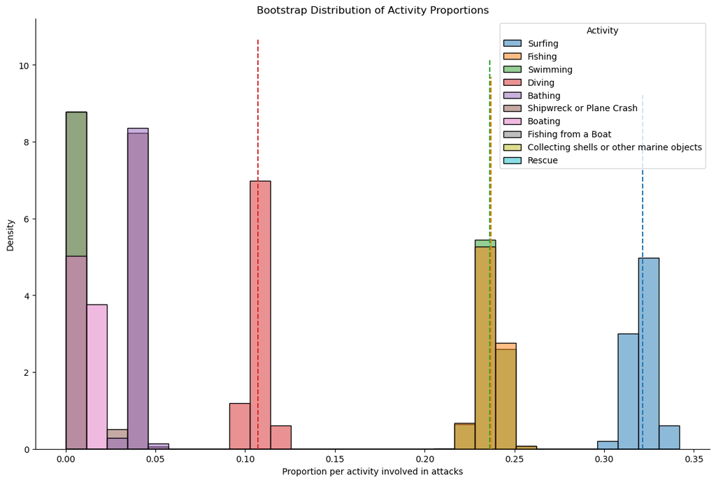

```python
#Plotting the bootstrap distribution
fig, ax = plt.subplots(figsize = (14, 9))
sns.histplot(data = boot_activities_proportions_df, x = 'proportion', hue = 'Activity',
             stat = 'density', bins = 30)
ax.set_xlabel('Proportion per activity involved in attacks')
ax.set_ylabel('Density')
ax.set_title('Bootstrap Distribution of Activity Proportions')
ax.vlines(0.32158450852452114, 0, ax.get_ylim()[1], color = 'tab:blue', linestyle = '--') #Surfing mean proportion across bootstrap samples
ax.vlines(0.23684697958324563, 0, ax.get_ylim()[1], color = 'tab:orange', linestyle = '--') #Fishing shark mean proportion across bootstrap samples
ax.vlines(0.23646074510629342, 0, ax.get_ylim()[1], color = 'tab:green', linestyle = '--') #Swimming shark mean proportion across bootstrap samples
ax.vlines(0.10694001262892022, 0, ax.get_ylim()[1], color = 'tab:red', linestyle = '--') #Diving shark mean proportion across bootstrap samples
ax.spines[['top', 'right']].set_visible(False)
plt.show()
```

### Reflecting on the data

Surfing (mean proportion = 0.32), fishing (mean proportion = 0.24), and swimming (mean proportion = 0.24) appear to be the most common activities associated with shark attacks. Surfing may have the highest rates due to its association with a greater number of hours spent in the water, in comparison to diving (mean proportion = 0.11), for example, where time in the water is limited by the constraints of equipment (ex. air supply).

## General Conclusions

From the above analyses, we might infer that risk of shark attacks is mainly a question of proximity; under which conditions are humans most likely to be in close contact with a shark? We can see that the sharks most likely to attack are also the most numerous, and that attacks are more likely to occur in regions that sharks frequent, while engaging in activities that prolong time in the water. Like many animals, sharks are curious and may choose to investigate a novel feature of their environment (i.e. a human in the water). This is not equivalent to predation, and though encounters with sharks can be dangerous or even (very rarely) deadly, they are not usually malicious (Neff & Hueter, 2013).

## Limitations

The categorical nature of this data limited the number of descriptive statistics that could be calculated, so analyses were focused on the frequencies and proportions of values and visualized accordingly.

## References

To get some insight on the possible reasons for these shark attack trends, I consulted the following journal articles:

Midway, S. R., Wagner, T., Burgess, G. H. (2019). Trends in global shark attacks. *Plos One, 14*(2), e0211049. https://doi.org/10.1371/journal.pone.0211049

Neff, C., Hueter, R. (2013). Science, policy, and the public discourse of shark "attack": A proposal for reclassifying human-shark interactions. *Journal of Environmental Studies and Sciences* 3, 65-73.https://doi.org/10.1007/s13412-013-0107-2

To read about and incorporate some coding methods and functions beyond what has been covered in the course, I consulted the following python, pandas and matplotlib documentation:

- Regular Expression Operations: https://docs.python.org/3/library/re.html#regular-expression-syntax
- Pandas.series.str.contains: https://pandas.pydata.org/docs/reference/api/pandas.Series.str.contains.html
- Pandas.DataFrame.replace: https://pandas.pydata.org/docs/dev/reference/api/pandas.DataFrame.replace.html
- Pandas.DataFrame.size: https://pandas.pydata.org/docs/reference/api/pandas.DataFrame.size.html
- Matplotlib Legend Guide: https://matplotlib.org/stable/users/explain/axes/legend_guide.html